# Tugas

Annisa Marwah

2026-09-01

```r
library(readxl)
library(lmtest)
library(dplyr)
library(TTR)
library(forecast)
library(orcutt)
library(HoRM)
```

# MARKET SHARE & PRICE

## Input Data

```r
data <- read_excel("Data 1 tugas praktikum 2.xlsx")
data
```

```
## # A tibble: 20 × 3
##    Period `Market share` Price
##     <dbl>          <dbl> <dbl>
##  1      1           3.63  0.97
##  2      2           4.2   0.95
##  3      3           3.33  0.99
##  4      4           4.54  0.91
##  5      5           2.89  0.98
##  6      6           4.87  0.9
##  7      7           4.9   0.89
##  8      8           5.29  0.86
##  9      9           6.18  0.85
## 10     10           7.2   0.82
## 11     11           7.25  0.79
## 12     12           6.09  0.83
## 13     13           6.8   0.81
## 14     14           8.65  0.77
## 15     15           8.43  0.76
## 16     16           8.29  0.8
## 17     17           7.18  0.83
## 18     18           7.9   0.79
## 19     19           8.45  0.76
## 20     20           8.23  0.78
```

## Plot Deret Waktu

Sebelum melakukan regresi, akan diperlihatkan plot time-series dari Market share dan Price pada periode 1-20.

```r
data.ts1<-ts(data$`Market share`)
data.ts1
```

```
## Time Series:
## Start = 1
## End = 20
## Frequency = 1
##  [1] 3.63 4.20 3.33 4.54 2.89 4.87 4.90 5.29 6.18 7.20 7.25 6.09 6.80 8.65 8.43
## [16] 8.29 7.18 7.90 8.45 8.23
```

```r
data.ts2<-ts(data$Price)
data.ts2
```

```
## Time Series:
## Start = 1
## End = 20
## Frequency = 1
##  [1] 0.97 0.95 0.99 0.91 0.98 0.90 0.89 0.86 0.85 0.82 0.79 0.83 0.81 0.77 0.76
## [16] 0.80 0.83 0.79 0.76 0.78
```

Berikut adalah Time Series Plot dari variabel Market share

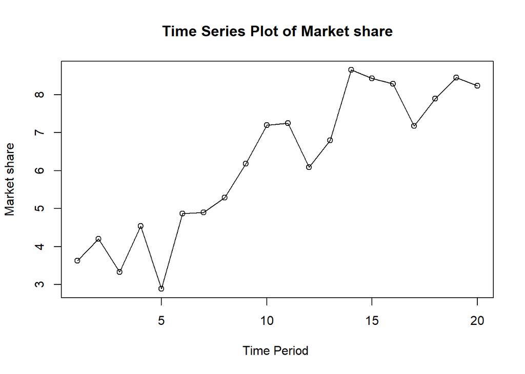

```r
ts.plot(data.ts1, xlab="Time Period ", ylab="Market share", main= "Time Series Plot of Market share")
points(data.ts1)
```

Berikut adalah Time Series Plot dari variabel Price

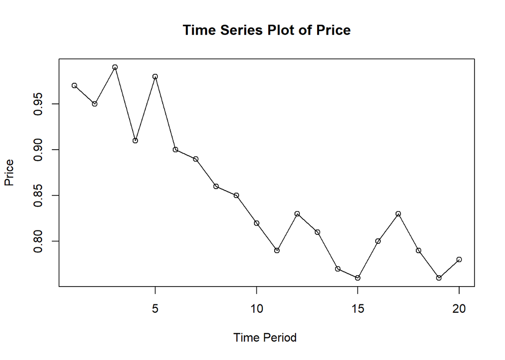

```r
ts.plot(data.ts2, xlab="Time Period ", ylab="Price", main= "Time Series Plot of Price")
points(data.ts2)
```

## Model Regresi Awal (OLS)

```r
model1 <- lm(`Market share` ~ Price, data = data)
summary(model1)
```

```
##
## Call:
## lm(formula = `Market share` ~ Price, data = data)
##
## Residuals:
##      Min       1Q   Median       3Q      Max
## -0.73068 -0.29764 -0.00966  0.30224  0.81193
##
## Coefficients:
##             Estimate Std. Error t value Pr(>|t|)
## (Intercept)   26.910      1.110   24.25 3.39e-15 ***
## Price        -24.290      1.298  -18.72 3.02e-13 ***
## ---
## Signif. codes:  0 '***' 0.001 '**' 0.01 '*' 0.05 '.' 0.1 ' ' 1
##
## Residual standard error: 0.4287 on 18 degrees of freedom
## Multiple R-squared:  0.9511, Adjusted R-squared:  0.9484
## F-statistic: 350.3 on 1 and 18 DF,  p-value: 3.019e-13
```

Model yang terbentuk (dari hasil summary):

$$\widehat{MarketShare} = 26.91 - 24.29 \times Price$$
(R-sq = 0.951)

Berdasarkan model regresi yang terbentuk, setiap kenaikan 1 satuan Price akan menyebabkan Market Share menurun sebesar 24,29 satuan, dengan asumsi faktor lain tetap. Sementara itu, nilai $R^2 = 0,9511$ menunjukkan bahwa 95,11% variasi Market Share dapat dijelaskan oleh variabel Price, sedangkan 4,89% sisanya dijelaskan oleh faktor lain di luar model.

## Pemeriksaan Asumsi Autokorelasi

### Plot sisaan terhadap waktu

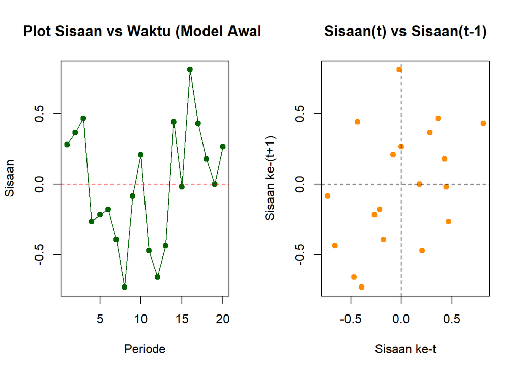

```r
sisaan1 <- residuals(model1)
par(mfrow = c(1, 2))
plot(data$Period, sisaan1, type = "o", pch = 19, col = "darkgreen",
     main = "Plot Sisaan vs Waktu (Model Awal)",
     xlab = "Periode", ylab = "Sisaan")
abline(h = 0, lty = 2, col = "red")

plot(sisaan1[-length(sisaan1)], sisaan1[-1], pch = 19, col = "darkorange",
     main = "Sisaan(t) vs Sisaan(t-1)",
     xlab = "Sisaan ke-t", ylab = "Sisaan ke-(t+1)")
abline(h = 0, v = 0, lty = 2)
```

```r
par(mfrow = c(1, 1))
```

Pola sisaan yang bergelombang/berkelanjutan (tidak acak) mengindikasikan kemungkinan autokorelasi positif.

### Uji Durbin-Watson

```r
dwtest(model1)
```

```
##
##  Durbin-Watson test
##
## data:  model1
## DW = 1.1358, p-value = 0.009813
## alternative hypothesis: true autocorrelation is greater than 0
```

Berdasarkan Uji Durbin-Watson, diperoleh nilai DW = 1,1358 dengan p-value = 0,009813. Karena p-value < 0,05, maka tolak
$$H_0$$
. Artinya, terdapat autokorelasi positif pada residual model, sehingga asumsi tidak adanya autokorelasi belum terpenuhi.

## Penanganan Autokorelasi dengan Cochrane-Orcutt

```r
model_co <- cochrane.orcutt(model1)
summary(model_co)
```

```
## Call:
## lm(formula = `Market share` ~ Price, data = data)
##
##             Estimate Std. Error t value  Pr(>|t|)
## (Intercept)  26.7221     1.6329  16.365 7.713e-12 ***
## Price       -24.0841     1.9385 -12.424 5.903e-10 ***
## ---
## Signif. codes:  0 '***' 0.001 '**' 0.01 '*' 0.05 '.' 0.1 ' ' 1
##
## Residual standard error: 0.3955 on 17 degrees of freedom
## Multiple R-squared:  0.9008 ,  Adjusted R-squared:  0.895
## F-statistic: 154.4 on 1 and 17 DF,  p-value: < 5.903e-10
##
## Durbin-Watson statistic
## (original):    1.13582 , p-value: 9.813e-03
## (transformed): 1.95804 , p-value: 4.151e-01
```

Cochrane-Orcutt melakukan differencing tergeneralisasi:
$$Y*_t = Y_t - rho \times Y_{(t-1)} , X*_t = X_t -
rho \times X_{(t-1)}$$
dengan rho diestimasi dari otokorelasi lag-1 sisaan (rho_hat = 0.418),lalu meregresikan Y* terhadap X*.

Durbin-Watson setelah koreksi naik menjadi ~1.95 (mendekati 2), sudah berada pada daerah “tidak ada autokorelasi” (DW > dU = 1.41).

### Uji Durbin-Watson pada model terkoreksi

```r
sisaan_co <- model_co$residuals
dw_after <- sum(diff(sisaan_co)^2) / sum(sisaan_co^2)
cat("Durbin-Watson setelah Cochrane-Orcutt :", round(dw_after, 3), "\n")
```

```
## Durbin-Watson setelah Cochrane-Orcutt : 1.124
```

### Plot sisaan model terkoreksi

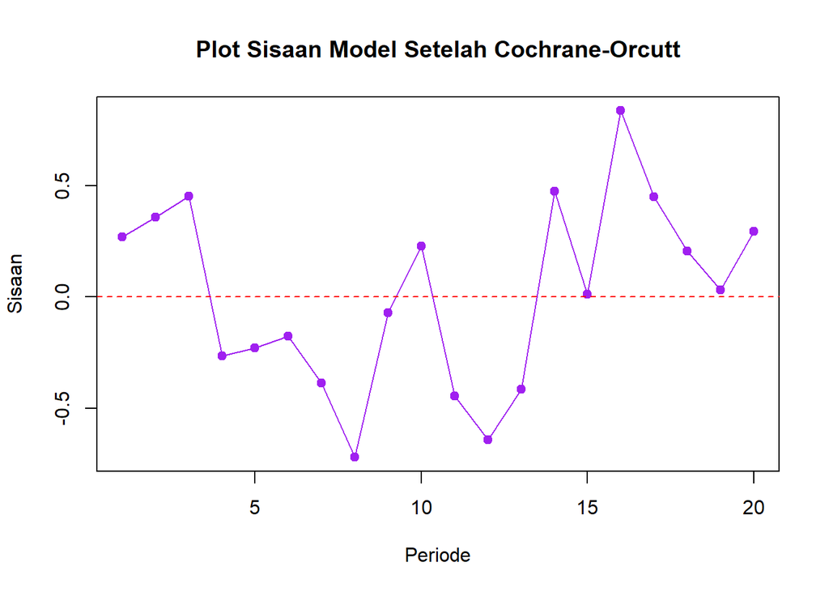

```r
plot(sisaan_co, type = "o", pch = 19, col = "purple",
     main = "Plot Sisaan Model Setelah Cochrane-Orcutt",
     xlab = "Periode", ylab = "Sisaan")
abline(h = 0, lty = 2, col = "red")
```

# SALES & ADVERTISING

## Input Data

```r
dt <- read_excel("Data 2 tugas praktikum.xlsx")
dt
```

```
## # A tibble: 40 × 3
##     Year Sales Advertising
##    <dbl> <dbl>       <dbl>
##  1  1975  11.7         9.4
##  2  1976  12           9.6
##  3  1977  12.3        10
##  4  1978  12.8        10.4
##  5  1979  13.1        10.8
##  6  1980  13.6        10.9
##  7  1981  13.9        11.7
##  8  1982  14.4        12.2
##  9  1983  14.7        12.5
## 10  1984  15.3        12.9
## # ℹ 30 more rows
```

## Plot Deret Waktu

Sebelum melakukan regresi, akan diperlihatkan plot time-series dari Sales dan Advertising pada periode 1975-2014.

```r
dt.ts1<-ts(dt$Sales)
dt.ts1
```

```
## Time Series:
## Start = 1
## End = 40
## Frequency = 1
##  [1] 11.7 12.0 12.3 12.8 13.1 13.6 13.9 14.4 14.7 15.3 15.5 15.8 16.1 16.6 16.9
## [16] 16.7 16.9 17.4 17.6 17.9 18.0 18.0 18.0 18.2 18.2 18.3 18.6 19.2 19.3 19.5
## [31] 19.2 19.3 19.5 20.0 20.0 19.9 19.8 19.9 20.2 21.0
```

```r
dt.ts2<-ts(dt$Advertising)
dt.ts2
```

```
## Time Series:
## Start = 1
## End = 40
## Frequency = 1
##  [1]  9.4  9.6 10.0 10.4 10.8 10.9 11.7 12.2 12.5 12.9 13.0 13.2 13.8 14.2 14.6
## [16] 14.4 15.0 15.4 15.7 15.9 15.9 16.0 16.3 16.2 16.8 17.3 17.6 18.1 18.3 18.5
## [31] 18.7 18.9 19.2 20.0 20.0 20.3 20.4 21.0 21.5 22.1
```

Berikut adalah Time Series Plot dari variabel Sales

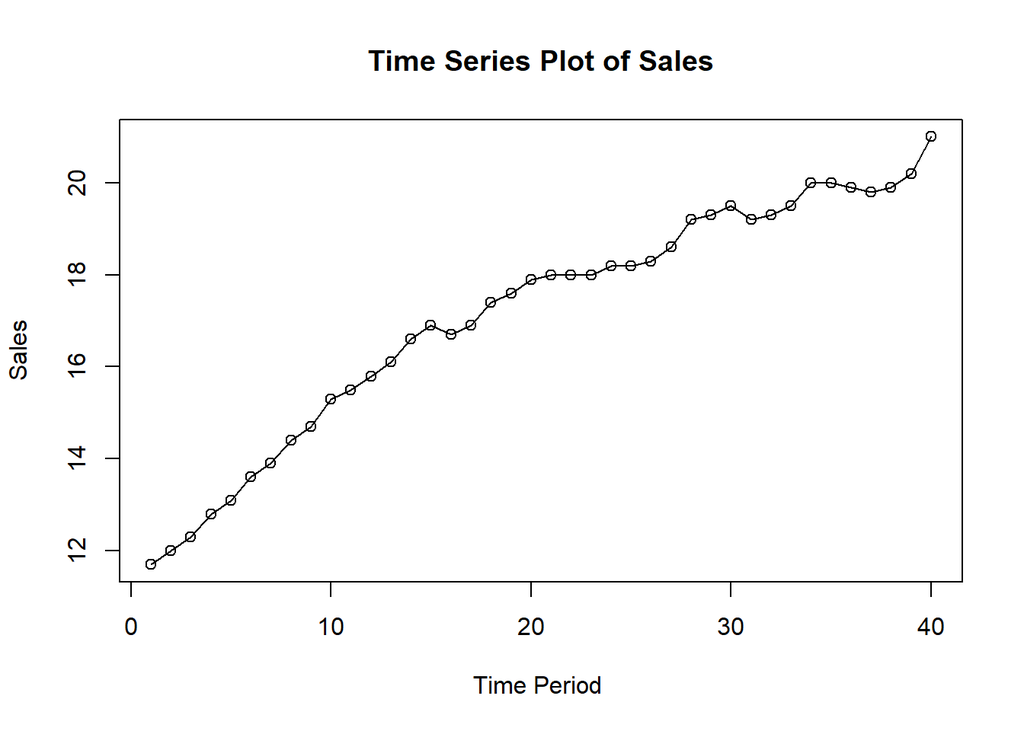

```r
ts.plot(dt.ts1, xlab="Time Period ", ylab="Sales", main= "Time Series Plot of Sales")
points(dt.ts1)
```

Berikut adalah Time Series Plot dari variabel Advertising

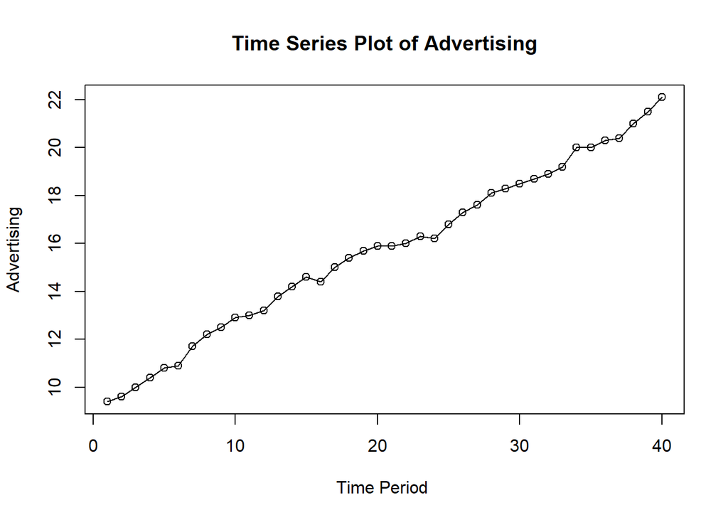

```r
ts.plot(dt.ts2, xlab="Time Period ", ylab="Advertising", main= "Time Series Plot of Advertising")
points(dt.ts2)
```

## Model Regresi Awal (OLS)

```r
model2 <- lm(Sales ~ Advertising, data = dt)
summary(model2)
```

```
##
## Call:
## lm(formula = Sales ~ Advertising, data = dt)
##
## Residuals:
##      Min       1Q   Median       3Q      Max
## -1.04041 -0.40582  0.08673  0.45425  0.73785
##
## Coefficients:
##             Estimate Std. Error t value Pr(>|t|)
## (Intercept)  5.96674    0.38314   15.57   <2e-16 ***
## Advertising  0.71040    0.02379   29.87   <2e-16 ***
## ---
## Signif. codes:  0 '***' 0.001 '**' 0.01 '*' 0.05 '.' 0.1 ' ' 1
##
## Residual standard error: 0.5301 on 38 degrees of freedom
## Multiple R-squared:  0.9591, Adjusted R-squared:  0.9581
## F-statistic:   892 on 1 and 38 DF,  p-value: < 2.2e-16
```

Model yang terbentuk:

$$\widehat{Sales} = 5.965 + 0.710 \times
Advertising$$
(R² ≈ 0.960)

Berdasarkan model regresi yang terbentuk, setiap kenaikan 1 satuan Advertising akan menyebabkan Sales meningkat sebesar 0,710 satuan. Selain itu, nilai
$$R^2 = 0,9591$$
menunjukkan bahwa 95,91% variasi Sales dapat dijelaskan oleh variabel Advertising, sedangkan 4,09% sisanya dijelaskan oleh faktor lain di luar model.

## Pemeriksaan Asumsi Autokorelasi

### Plot sisaan terhadap waktu

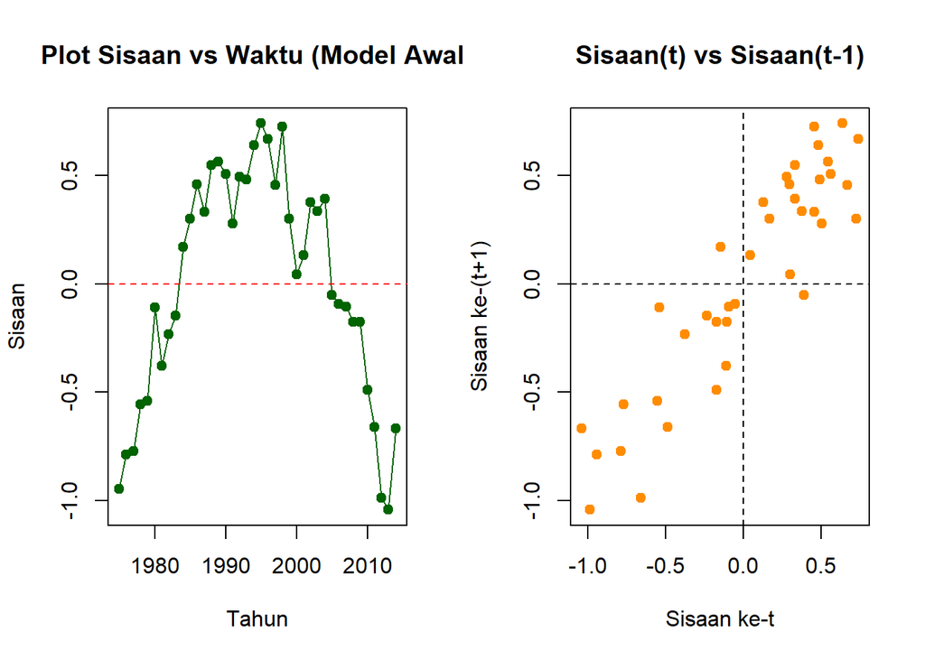

```r
sisaan3 <- residuals(model2)

par(mfrow = c(1, 2))
plot(dt$Year, sisaan3, type = "o", pch = 19, col = "darkgreen",
     main = "Plot Sisaan vs Waktu (Model Awal)",
     xlab = "Tahun", ylab = "Sisaan")
abline(h = 0, lty = 2, col = "red")

plot(sisaan3[-length(sisaan3)], sisaan3[-1], pch = 19, col = "darkorange",
     main = "Sisaan(t) vs Sisaan(t-1)",
     xlab = "Sisaan ke-t", ylab = "Sisaan ke-(t+1)")
abline(h = 0, v = 0, lty = 2)
```

```r
par(mfrow = c(1, 1))
```

Plot sisaan terhadap waktu memperlihatkan pola bergelombang/berkesinambungan (sisaan positif cenderung diikuti sisaan positif lagi, begitu pula sisaan negatif) — indikasi kuat adanya autokorelasi positif.

### Uji Durbin-Watson

```r
dwtest(model2)
```

```
##
##  Durbin-Watson test
##
## data:  model2
## DW = 0.16096, p-value < 2.2e-16
## alternative hypothesis: true autocorrelation is greater than 0
```

Berdasarkan Uji Durbin-Watson, diperoleh nilai DW = 0,16096 dengan p-value < 2,2 × 10⁻¹⁶. Karena p-value < 0,05, maka tolak
$$H_0$$
. Artinya, terdapat autokorelasi positif yang signifikan pada residual model, sehingga asumsi tidak adanya autokorelasi belum terpenuhi.

## Penanganan Autokorelasi dengan Cochrane-Orcutt

```r
model_co2 <- cochrane.orcutt(model2)
summary(model_co2)
```

```
## Call:
## lm(formula = Sales ~ Advertising, data = dt)
##
##              Estimate Std. Error t value  Pr(>|t|)
## (Intercept) 10.412502   1.489489   6.991 2.917e-08 ***
## Advertising  0.481225   0.076627   6.280 2.624e-07 ***
## ---
## Signif. codes:  0 '***' 0.001 '**' 0.01 '*' 0.05 '.' 0.1 ' ' 1
##
## Residual standard error: 0.1868 on 37 degrees of freedom
## Multiple R-squared:  0.516 ,  Adjusted R-squared:  0.5029
## F-statistic: 39.4 on 1 and 37 DF,  p-value: < 2.624e-07
##
## Durbin-Watson statistic
## (original):    0.16096 , p-value: 7.701e-20
## (transformed): 1.95447 , p-value: 3.973e-01
```

Metode Cochrane-Orcutt melakukan differencing tergeneralisasi:

$$Sales^*_t = Sales_t - \rho \,
Sales_{t-1}, \qquad
Advertising^*_t = Advertising_t - \rho \, Advertising_{t-1}$$

dengan $\hat{\rho}$ diestimasi dari otokorelasi lag-1 sisaan model awal ($\hat{\rho} \approx 0.893$ — sangat tinggi, konsisten dengan DW awal yang sangat rendah).

### Uji Durbin-Watson pada model terkoreksi

```r
sisaan_co2 <- model_co2$residuals
dw_after2 <- sum(diff(sisaan_co2)^2) / sum(sisaan_co2^2)
cat("Durbin-Watson setelah Cochrane-Orcutt :", round(dw_after, 3), "\n")
```

```
## Durbin-Watson setelah Cochrane-Orcutt : 1.124
```

### Plot sisaan model terkoreksi

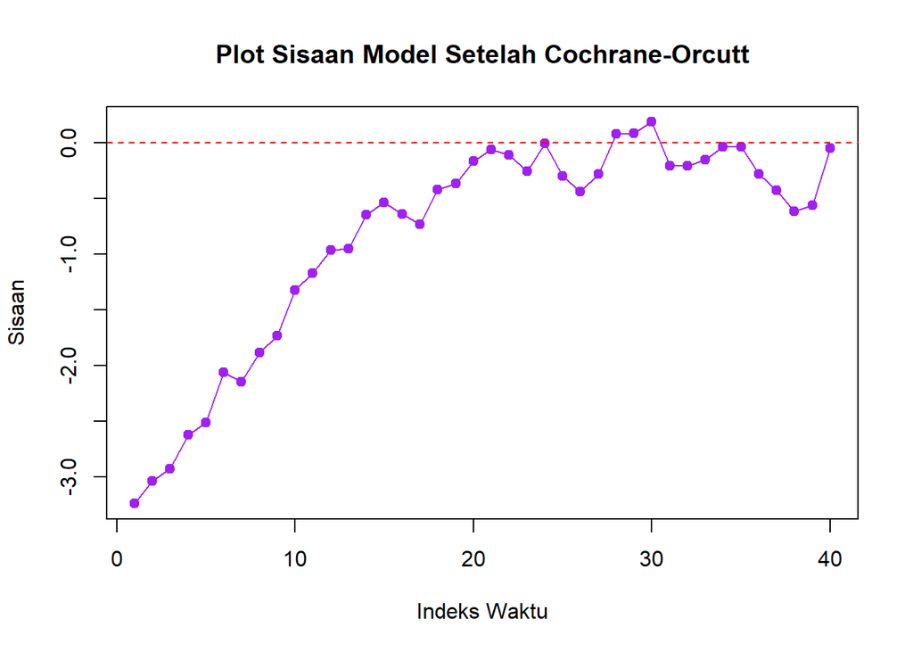

```r
plot(sisaan_co2, type = "o", pch = 19, col = "purple",
     main = "Plot Sisaan Model Setelah Cochrane-Orcutt",
     xlab = "Indeks Waktu", ylab = "Sisaan")
abline(h = 0, lty = 2, col = "red")
```